# Identifying the Patterns Present Within Red and White Wine and the Most Accurate Algorithm for Supervised Classification.

Daniel Majer

# Abstract

The grapevine Vitis Vinifera has an approximate 5000-10000 grape varieties throughout the world covering 0.5% of the world’s agricultural land. Although there are many distinctive types, only a few are commercially successful therefore many business stakeholders involved with wine look to data mining methods to identify trends within the data determine the winning combination of chemical and physical properties of wines. The purpose of this report was to identify the patterns present in the dataset by performing principal component analysis and accurately classify the red and white wines using a number of supervised classification techniques. The results of PCA revealed that the red and white wine observation formed two distinctive clusters with majority of the variation occurring for the first 3 PCs. Overall all supervised classification algorithms yielded high performance metrics due to the pre-processing decisions enacted on the data. LDA was the most accurate classification method followed closely by KNN due to the separation of red and white clusters. The most important aspects when classifying red and white wines was sulfur dioxide, chlorides and volatile acidity whilst the least important aspects in differentiating was residual sugar, citric acid and alcohol. Differences between wine types are most likely due to the inherent differences that occur during the fermentation process whilst the least important aspect for classification are fermentation strategies similar to both wine types.

# Introduction

The grapevine Vitis Vinifera has been cultivated throughout many cultures over world for thousands of years. This common grapevine can attribute an estimated 5000-10000 of red and white grape varieties which collectively cover approximately 0.5% of the world’s agricultural land (del-Campo-Sanchez et al. (2019)). Although there are many different varieties, only a few grape types are commercially popular for the production of red and white wines respectively (del-Campo-Sanchez et al. (2019)). The key feature that distinguishes wine colour is the use of grapes during the fermentation process. Simplistically red wine is juiced and fermented with the skin intact whilst white wine only utilises the juice from green grapes (Ballester et al. (2009)). In the case of wine production, attaining quality is a complex and multidimensional aspect and mainly related to the sensory characteristics that each sip brings to the tasting experience (Ferreira et al. (2009)). For this reason many business stakeholders involved with the production and consumption of wine look to data mining methods to find inferences within their collected data (“Washington: For Bing’s Kevin White, Red Wine and Data Science Are the Perfect Pairing” 2014).

The purpose of this report is to identify the patterns present in the datset by performing principal component analysis and accurately classify the wine type of the dataset using a number of supervised classification techniques.

# Data

The dataset “Wine Quality” was sources from the Introduction to Data Mining Folder on the Learn James Cook University Website. This dataset was created by Paulo Cortez (Univ. Minho), Antonio Cerdeira, Fernando Almeida, Telmo Matos and Jose Reis (CVRVV) in 2009. The dataset was collected in an observation study which recorded the various attributes of red and white wines respectively. The winequality.names file specified that the two dataset are related to the red and white variants pf the Portuguese “Vinho Verde” wine. Due to the privacy and logistical issues, the names of the wines were removed from the original dataset and only the physicochemical and sensory variables were reported in the dataset. The wine quality dataset was separated into a red and white dataset in which the red dataset consisted of 1599 observation and 12 attributes, whilst the white contained the same number of attributes with 4898 observations. The following table displays the variable types present in the combined wine quality dataset:

```r
wine_metadata_table <- data.frame(
  Attribute = c("fix.acidity", "volatile.acidity", "citric.acid", "residual.sugar", "chlorides", "free.sulfur.dioxide",
              "total.sulfur.dioxide", "desnity", "pH", "sulphates", "alcohol", "quality", "wine_type"),
  Type = c(rep("numeric continuous", 11), "categorical ordinal", "categorical nominal"),
  Description = c("acidity concentration, (tartaric acid)g/dm^3", "volatile acidity concentraion, (acetic acid)g/dm^3)",
                  "citric acid concentration, g/dm^3", "residual sugar concentration, g/dm^3",
                  "chlorides concentration, (sodium chloride)g/dm^3","free sulfur dioxide concentration, mg/dm^3",
                  "total sulfur dioxide concentration, mg/dm^3", "density concentration, g/dm^3",
                  "estimation of pH level", "sulphates concentration, (potassium sulphate)g/dm^3",
                  "alcohol percentage in absolute units", "score of wine quality between 0 and 10",
                  "wine type"))

kable(wine_metadata_table) %>%
  kable_styling() %>%
  footnote(general ="shows the metadata table for the wine quality dataset.",
           general_title = "Table 1:",footnote_as_chunk = T, title_format = c("bold", "underline"))
```

| Attribute | Type | Description |
| --- | --- | --- |
| fix.acidity | numeric continuous | acidity concentration, (tartaric acid)g/dm^3 |
| volatile.acidity | numeric continuous | volatile acidity concentraion, (acetic acid)g/dm^3) |
| citric.acid | numeric continuous | citric acid concentration, g/dm^3 |
| residual.sugar | numeric continuous | residual sugar concentration, g/dm^3 |
| chlorides | numeric continuous | chlorides concentration, (sodium chloride)g/dm^3 |
| free.sulfur.dioxide | numeric continuous | free sulfur dioxide concentration, mg/dm^3 |
| total.sulfur.dioxide | numeric continuous | total sulfur dioxide concentration, mg/dm^3 |
| desnity | numeric continuous | density concentration, g/dm^3 |
| pH | numeric continuous | estimation of pH level |
| sulphates | numeric continuous | sulphates concentration, (potassium sulphate)g/dm^3 |
| alcohol | numeric continuous | alcohol percentage in absolute units |
| quality | categorical ordinal | score of wine quality between 0 and 10 |
| wine_type | categorical nominal | wine type |

Table 1: shows the metadata table for the wine quality dataset.

# Methods

**Importing and Preprocessing the Data**: The red and wine data was imported into R using the `read.csv()` function and wine type was added to each respective dataset using `rep()` before they were combined. This additional column was converted to a factor and acted as a binary categorical variable for the analysis of this report. The quality variable was then removed from the dataset. The various functions used to import and prep-process the data were from the `base r` and `tidyverse` packages (Wickham (2019)).

```r
#import wine data
red_data<- read.csv(file = "winequality-red.csv", sep = ";", header = T)
white_data <- read.csv(file = "winequality-white.csv", sep = ";", header = T)
#add wine class to both datasets
red_data$wine_type = rep("red", nrow(red_data))
white_data$wine_type = rep("white", nrow(white_data))
#combine red and white datasets
combined_wine_data <- rbind(red_data, white_data)
combined_wine_data$wine_type <- factor(combined_wine_data$wine_type)
#dropping quality rating
combined_wine_data <- combined_wine_data[,-12]
```

**Data Exploration and Visualisation**: The `dim()`, `str()` and `summary()` functions were using from `base r` to inspected to identify any potential problems with the dataset. The `summary()` function indicated that the dataset contained no missing values and was mainly comprised of white wine observations. To ensure the predictive analysis contained the same number of red and white wine observations, the combined wine dataset was evenly sampled, using the `downsample()` function from the `caret` package (Kuhn (2020)).

```r
#Inspecting data
dim(combined_wine_data) # get dimension of df: 6497 rows,  12 cols
summary(combined_wine_data) #indcates majority of wine observations are white
str(combined_wine_data)

#downsample from caret package used to get even distribution of red and white wine observations
set.seed(0)
even_combined_wine_data <- combined_wine_data
even_combined_wine_data<- downSample(x = combined_wine_data[,-12], y = combined_wine_data$wine_type, list = F, yname = "wine_type")
```

Each numeric variable’s distribution was inspected for each wine type using comparative boxplots using the geom_boxplot() extension of ggplot2 (Wickham et al. (2019)). This was implemented using the `melt()` function from the `reshape` package (Wickham (2018)) which created a long dataset making it easy to facet each boxplot by the numeric variable. The dataset was normalised using the `scale()` function contained within `base r` which used a z score normalisation method to reducing the effect of outliers without removing them. A correlation plot was created by firstly calculating the correlation matrix (`rcorr()`) function and then creating a correlation plot (`corrplot()`). These functions were sourced from the `Hmisc` and `corrplot` packages respectively (Harrell (2020), Wei and Simko (2017)).

```r
#separateing red_data into predictors and labels
wine_numerical_predictors <- even_combined_wine_data[,1:11]
wine_class <- even_combined_wine_data[,12]

#normalise using z score method
even_wine_norm_data<- as.data.frame(scale(wine_numerical_predictors))
even_wine_norm_data <- cbind(even_wine_norm_data, wine_class) #adding class to normalised dataset
```

## Principal Component Analysis

PCA of a data matrix extracts the dominate patterns in a matrix in terms of the complementary set of score and loading points. This means more responsibility falls to the analyst to formulate inferences in the dataset such as principal component (PC) projections, Proportion of Explained Variance (PVE), PC regressions. This analysis is dependent on the scaling of the matrix and thus must be specified (Zhang and Castelló (2017)).

**Performing PCA**: PCA was performed using the normalised wine predictors using the `prcomp()` function from `base r` and scale was set to FALSE. The proportion of explained variation (PVE) was then calculated into a new data frame by squaring the “sdev” (standard deviation) results and dividing it by the total PC variation.

```r
# Performing PCA
pca_wine <- prcomp(even_wine_norm_data[,1:11], scale = F)

#calculate Porportion of Variation Explained (PVE)
PCA_Var <- pca_wine$sdev^2
PVE_wine <- as.data.frame(round( PCA_Var/sum(PCA_Var),4))
colnames(PVE_wine) <- "PVE"

#Add labels and cummulative PVE
PVE_wine <- PVE_wine %>%
  mutate(eigen_val = PVE*10,
         PVE = PVE*100,
         cum_PVE = cumsum(PVE),
         PC = paste(c("PC"), 1:11, sep = ""),
         explained_90_per = ifelse(cum_PVE<92, "Y", "N"),
         eig_great_than_1 = ifelse(eigen_val>1, "Y","N")) %>%
  dplyr::select(PC, PVE, eigen_val, cum_PVE, explained_90_per, eig_great_than_1)

#plotting the first 3 PCA resutlss on 3D scatter
x = pca_wine$x[,1]
y = pca_wine$x[,2]
z = pca_wine$x[,3]

wine_class <- even_wine_norm_data$wine_class
wine_class <- factor(wine_class,
                     levels = c("red", "white"),
                     labels = c(0,1))
```

**Visualisation and Interpretation of PCA**: Two bar graphs were constructed, the first graph showcased the PVE each PC contributed and the second displayed accumulative PVE of the PCs. These graphs were used to identify which dimension or PC contributed to 90% of the explained variation (Zhang and Castelló (2017)). The two PCs that contributed most of the variation of the dataset are PC1 and PC2, and thus a biplot was used to showcase the patterns in the dataset and the effect each variable had on these patterns. This was generated using the `autoplot()` function from the `ggfortify` package (Horikoshi and Tang (2020)).

```r
#graphed PC variation
PVE_wine %>%
  ggplot(aes(x=fct_reorder(PC, cum_PVE), y = PCA_Var, fill = explained_90_per))+
  geom_bar(stat = "identity") +
  geom_text(aes(label = paste(cum_PVE, "%", sep= "")))+
  theme(axis.text.x = element_text(angle=60, hjust=1), legend.position = "none")+
  ggtitle("Principal Component Percent Variation")+
  xlab("Principal Component")+
  ylab("PC variation (%)")+
  scale_fill_discrete(name = "Contributes to 90%\nof variation")

#PVE Accumulation Graph
PVE_wine %>%
  ggplot(aes(x = fct_reorder(PC, cum_PVE), y = cum_PVE, fill = explained_90_per))+
  geom_bar(stat = "identity", color = 'black')+
  geom_hline(yintercept = 90, linetype = "dashed", size = 1)+
  geom_text(aes(label = paste(PVE, "%", sep= "")), vjust = -0.25)+
  theme(axis.text.x = element_text(angle=60, hjust=1))+
  labs(x = "Principal Component", y = "Accumulative PVE", fill = "Contributes to\n90% of variation",
       title = "Accumulative PVE for Red Wine")

# Biplopt showing the loading of each variable
autoplot(pca_wine, data = even_wine_norm_data, colour = "wine_class",
         loadings = TRUE, loadings.colour = 'blue',
         loadings.label = TRUE, loadings.label.size = 3, loadings.label.colour = "black")
```

## Supervised Classification

**Separating the Data**: Prior to beginning classification, the training and testing indices were compiled by sampling the dimensions of the normalised wine dataset in order to randomly select the two datasets necessary for generative analysis.

```r
#############################################################################################################
#Separating data into test and training
#get training (20% of dataset) and test (80% of dataset) datasets
set.seed(123)#sets the random gnerateor where to begin generating random numbers
num_wine_obs <- dim(even_wine_norm_data)[1]
wine_test_index <- sample(num_wine_obs, size = as.integer(num_wine_obs*0.2), replace = F) #test data indexes
wine_training_index <- -wine_test_index #generates negative indices to remove test data
wine_test_data <- even_wine_norm_data[wine_test_index,]
wine_training_data <- even_wine_norm_data[wine_training_index,]
#######################################################################################################
```

### Training Naive Bayes, Linear Discriminant Analysis and Quadratic Discriminant Analysis

**Training Naïve Bayes (NB), Linear Discriminant Analysis (LDA), Quadratic Discriminant Analysis (QDA)**: these three models are based off the Bayes Theorem used to calculate conditional probability, the probability of event A given that event B has occurred [denoted as P(A|B)]. Each model have their own assumptions which produce different performance metrics of the same test data. The formula used to calculate the posterior probabilities (P(A|B) occurring) can be calculated using the formula:
$$\mathrm{P}(A \mid B) = \frac{P(B|A)*P(A)}{P(B)}$$

**Where**: $\mathrm{P}(A \mid B)$ is the Posterior Probability, $\mathrm{P}(B \mid A)$ is the Prior Probability, $\mathrm{P}(A)$ is the probability of event A occurring, $\mathrm{P}(B)$ is the probability of event B occurring

NB is the most flexible model of mention supervised models as it assumes that all predictors correlate in some way, thus making the model naive (Stephens, Huerta, and Linares (2018)). LDA and QDA have a linear and quadratic decision surface respectively which means that QDA is more flexible at classifying overlapping clusters whilst LDA is better at classifying separated clusters (Wu et al. (1996)). This is because QDA assumes all numeric features have different covariances whilst LDA assumes all covariance are the same. One assumption that the three models share is that they assume that each numeric predictor follows a Gaussian distribution (Wu et al. (1996), Stephens, Huerta, and Linares (2018)). Thus if variables in a dataset do not it can impair the accuracy of the classification.

The three supervised models were trained in succession and confusion matrices were generated to reveal the results of predicting the test data. The NB algorithm, `naive_bayes()` was attained from the `naivebayes` package (Majka (2020)) and LDA and QDA models, `lda()` and `qda()`, from the `MASS` package (Ripley (2019b)).

```r
nb_fit <- naive_bayes(wine_class~., data = wine_training_data)
nb_pred_class <- predict(nb_fit, wine_test_data, type = 'class')
nb_cm <- table(nb_pred_class, wine_test_data[,12])

lda_fit <- lda(wine_class~., data = wine_training_data)
lda_pred_class <- predict(lda_fit, wine_test_data, type = 'class')$class
lda_cm <- table(lda_pred_class, wine_test_data[,12])

qda_fit <- qda(wine_class~., data = wine_training_data)
qda_pred_class <- predict(qda_fit, wine_test_data, type = 'class')$class
qda_cm <- table(qda_pred_class, wine_test_data[,12])
```

**k Nearest Neighbour Cluster**: KNN is another method of supervised classification that predicts new data after previously being training with data containing binary class. The benefit of this model compared to other classifiers is that it categorises datapoints based off the distance between 2 points in which it may be generalised that half of the total information needed for classification purposes is contained in the nearest neighbour (Li, Li, and Wei (2018)). KNN attempts to estimate the conditional distribution of Y given X [denoted as P(Y|X)] and then classify a given observation according to the highest estimated probability. The formula used to calculate this is:
$$\mathrm{P}(Y = j \mid X = x_{0}) = \frac{1}{K}\sum_{i \in N_{0}}{I(y_{i}=j)}$$

**Where**: K is a positive integer, is a test observation, $N_{0}$ is the K points in the training data that are closest to $x_{0}$, and j is the class.

```r
#performing KNN supervised classification
set.seed(0)
ctrl <- trainControl(method="repeatedcv",repeats = 3)
knnFit <- train(wine_class ~ ., data = wine_training_data, method = "knn", trControl = ctrl, preProcess = c("center","scale"),tuneLength = 20)
#revealled that k = 9 had the highest accuracy

#### Perform supervised KNN where k = 9
knn_pred_class<- knn(train = wine_training_data[,1:11], test = wine_test_data[,1:11],
                   cl = wine_training_data$wine_class, k = 9, prob = T)

knn_cm <- table(knn_pred_class, wine_test_data$wine_class)
```

**Model Evaluation**: The 6 metrics were user to evaluate the performance of the classification models which included, Accuracy, Error, Precision, Recall value, F1 score and area under the curve (AUC). To calculate and display this, three user defined functions were implemented, a function that calculated the AUC of a model utilising the `ROCR` package (Sing et al. (2015)), a function that calculated and returned a list of the 6 metrics and a function that formatted the metrics into a data frame which used the `kable()` function and extensions from`knitr` (Xie (2019)) and `kableExtra()` packages (Zhu (2019)).

```r
#Calculates AUC
calculate_auc_val <- function(predicted, observed){
  predicted = ifelse(predicted == "red", 1, 0)
  observed = ifelse(observed == "red", 1, 0)
  Pred_Obj <- prediction(predicted, observed) #evaluates classifier
  auc <- performance(Pred_Obj, measure = "auc") #calculates performance
  auc <- auc@y.values[[1]] #gets AUC value
  return(auc)
}

#Calculates evaluation metrics for NB, LDA QDA and KNN models
calc_metrics <- function(conf_matrix, pred_class, wine_test_class){
  accuracy <- sum(diag(conf_matrix))/sum(conf_matrix) #calculating the accuracy metric
  error <- 1-accuracy #calculating the error metric
  precision <- conf_matrix[1,1]/sum(conf_matrix[1,]) #calculating the precision metric
  recall_val <-  conf_matrix[1,1]/sum(conf_matrix[,1]) #calculating the recall metric
  f1_score <- 2*precision * recall_val/(precision + recall_val) #calculating the f1_score metric
  auc <- calculate_auc_val(pred_class, wine_test_class) #calculating AUC
  metric_list <- list(accuracy, error, precision, recall_val, f1_score, auc) #storing all matrics in a list
  return(metric_list)
}

#Call metric function for all models
nb_metric_list <- calc_metrics(nb_cm, nb_pred_class, wine_test_data[,12])
lda_metric_list <- calc_metrics(lda_cm, lda_pred_class, wine_test_data[,12])
qda_metric_list <- calc_metrics(qda_cm, qda_pred_class, wine_test_data[,12])
knn_metric_list<- calc_metrics(knn_cm, knn_pred_class, wine_test_data[,12])

#generate a nice summary data frame for each model
display_model_evaluation <- function(metrics, model_name){
  display_acc <- paste(round(metrics[[1]]*100,2), "%", sep = "") # adds a % sign to accuracy and rounds to 2
  display_error <- display_err <- paste(round(metrics[[2]]*100,2), "%", sep = "") # adds a % sign to accuracy to 2
  display_prec <- round(metrics[[3]],2)
  display_recall <- round(metrics[[4]],2)
  display_F1<- round(metrics[[5]],2)
  display_auc <- round(metrics[[6]],4)
  summary_df <- rbind(display_acc, display_err, display_prec, display_recall, display_F1, display_auc)
  rownames(summary_df) <- c("Accuracy", "Error", "Precision", "Recall", "F1 Score", "AUC")
  colnames(summary_df) <- model_name
  return(as.data.frame(summary_df))
}

summary_nb_table <- display_model_evaluation(nb_metric_list, model_name = "Naive Bayes")
summary_lda_table <- display_model_evaluation(lda_metric_list , model_name = "LDA")
summary_qda_table <- display_model_evaluation(qda_metric_list , model_name = "QDA")
summary_knn_table <- display_model_evaluation(knn_metric_list, model_name = "kNN")

kable(cbind(summary_nb_table, summary_lda_table, summary_qda_table, summary_knn_table)) %>%
  kable_styling() %>%
  footnote(general ="shows the performance metrics of the 4 supervised classification models for the testing dataset",
           general_title = "Table 2")
```

# Results

## Boxplots

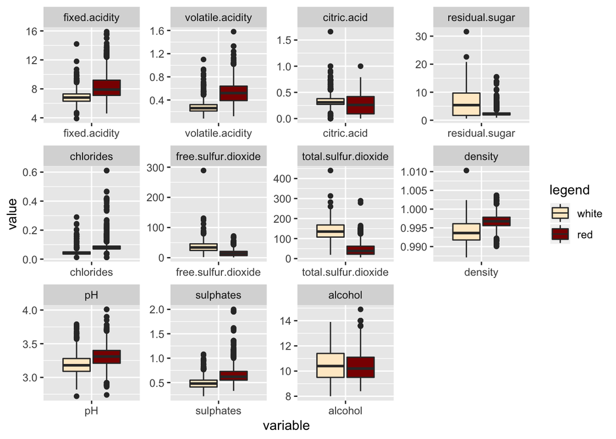

```r
#inspect distribution of each numerical variable
long_even_combined_wine_data<- melt(even_combined_wine_data, id.var = "wine_type")

long_even_combined_wine_data %>%
  ggplot(aes(x = variable, y = value))+
  geom_boxplot(aes(fill = fct_rev(wine_type))) +
  scale_fill_manual("legend", values = c("red" ="darkred", "white" = "blanchedalmond"))+
  facet_wrap(~ variable, scales = "free")
```

The comparative boxplots revealed that all numerical variable contained outliers. Majority of the white wine plots follow a normal distribution however, residual sugar and free sulphur dioxide display longer tails has a longer tail in the 4th quartile. For red wine, citric acid, volatile acidity, pH, free sulphur dioxide and alcohol all relatively follow a gaussian distribution. Fixed acidity and sulphates look positively skewed for red wine. In both wine types, Chloride looks to be impacted the most by outliers.

## Correlation Plot

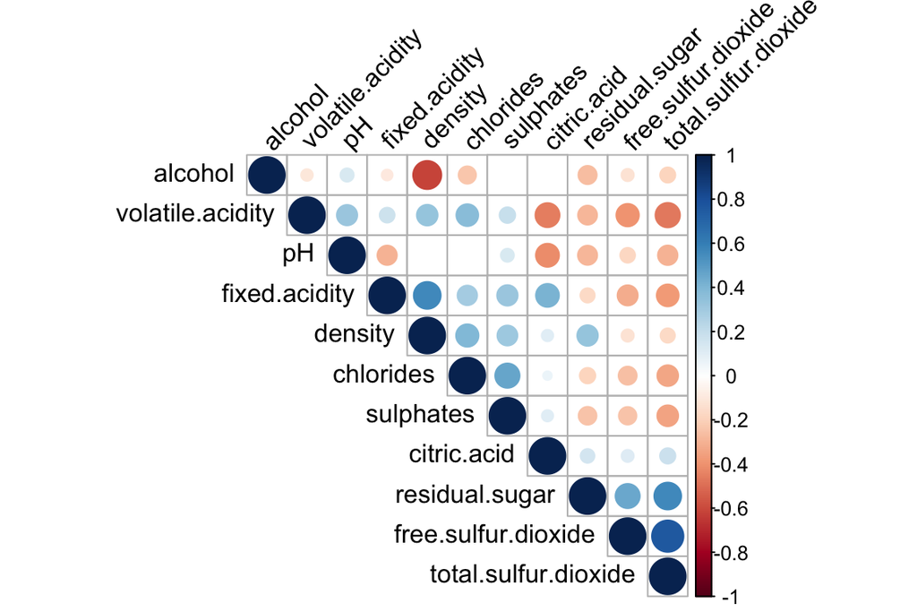

**Figure 2**: Corellation Plot of all numeric predictors

```r
wine_res <- rcorr(as.matrix(even_combined_wine_data[,1:11]))
corrplot(wine_res$r, type = "upper", order = "hclust",
         tl.col = "black", tl.srt = 45, p.mat = wine_res$P, sig.level = 0.01, insig = "blank")
```

# Principal Component Analysis

## PVE of each PC

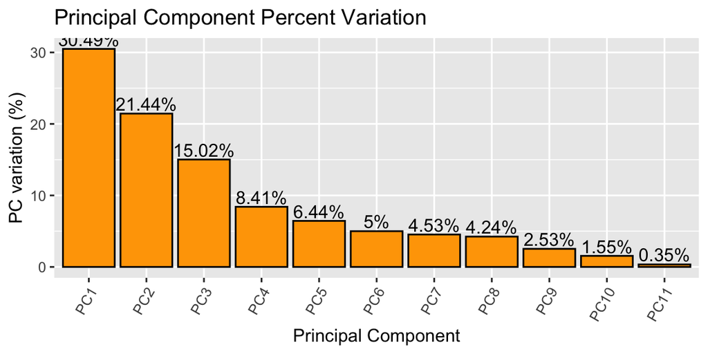

**Figure 3**: shows the PC percentage variation.

```r
PVE_wine %>%
  ggplot(aes(x=fct_reorder(PC, cum_PVE), y = PVE))+
  geom_bar(stat = "identity", color = "black", fill = "orange") +
  geom_text(aes(label = paste(PVE, "%", sep= "")), vjust = -0.25)+
  theme(axis.text.x = element_text(angle=60, hjust=1))+
  ggtitle("Principal Component Percent Variation")+
  xlab("Principal Component")+
  ylab("PC variation (%)")
```

## Accumulative PVE of each PC

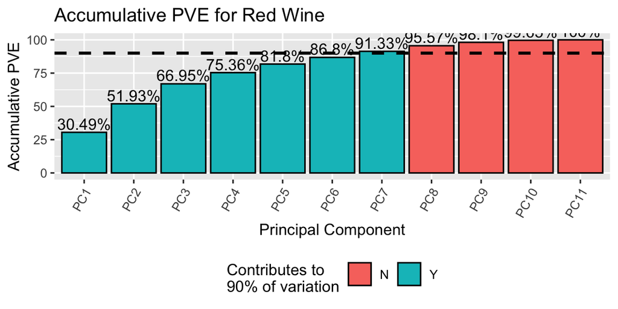

**Figure 4**: Shows the accumulative varaition of each PC and the PCs that contribute to 90% of explained PVE.

```r
PVE_wine %>%
  ggplot(aes(x = fct_reorder(PC, cum_PVE), y = cum_PVE, fill = explained_90_per))+
  geom_bar(stat = "identity", color = 'black')+
  geom_hline(yintercept = 90, linetype = "dashed", size = 1)+
  geom_text(aes(label = paste(cum_PVE, "%", sep= "")), vjust = -0.25)+
  theme(axis.text.x = element_text(angle=60, hjust=1), legend.position = "bottom")+
  labs(x = "Principal Component", y = "Accumulative PVE", fill = "Contributes to\n90% of variation",
       title = "Accumulative PVE for Red Wine")
```

## PCA Biplot of PC1 and 2

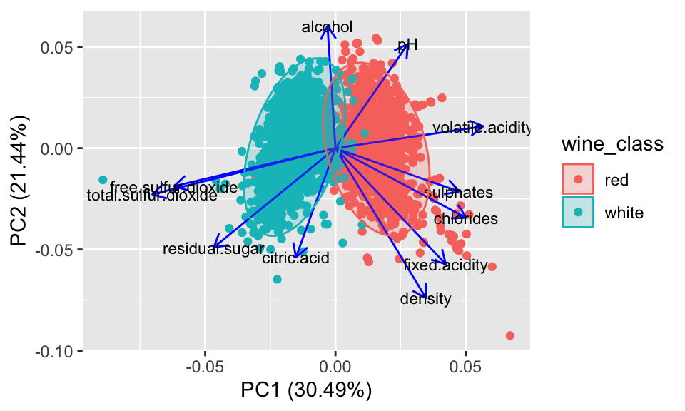

**Figure 5**: shows a biplot PC1 and PC2 and the labelled eigan vector of the dataset.

```r
autoplot(pca_wine, data = even_wine_norm_data, colour = "wine_class",
         loadings = TRUE, loadings.colour = 'blue',
         loadings.label = TRUE, loadings.label.size = 3, loadings.label.colour = "black",  frame = T, frame.type = "norm")
```

This plot displays that that the red and white observation form two distinct clusters which is highlighted by two ellipses. The blue arrows are the variable loadings which indicate free sulfur dioxide, total sulfur dioxide, volatile acidity, sulphates and chlorides have a stronger influence on PC1 than PC2 whilst, alcohol, citric acid, pH and density seem to have a larger effect on PC2 compared to PC1. Residual sugar, fixed acidity and pH show a relatively equal influence on PC1 and PC2 as the arrows are directed at an equal orientation between PC1 and PC2.

# Supervised Analysis Evaulation

## Evaulation Table

```r
kable(cbind(summary_nb_table, summary_lda_table, summary_qda_table, summary_knn_table), align = "c") %>%
  kable_styling() %>%
  footnote(general ="shows the performance metrics of the 4 supervised classification models for the testing dataset",
           general_title = "Table 2: ",footnote_as_chunk = T, title_format = c("bold", "underline"))
```

|  | Naive Bayes | LDA | QDA | kNN |
| --- | --- | --- | --- | --- |
| Accuracy | 97.34% | 98.9% | 97.81% | 98.59% |
| Error | 2.66% | 1.1% | 2.19% | 1.41% |
| Precision | 0.97 | 0.99 | 0.97 | 0.99 |
| Recall | 0.98 | 0.98 | 0.98 | 0.98 |
| F1 Score | 0.97 | 0.99 | 0.98 | 0.99 |
| AUC | 0.9735 | 0.989 | 0.9782 | 0.9859 |

Table 2: shows the performance metrics of the 4 supervised classification models for the testing dataset

## Variable Importance

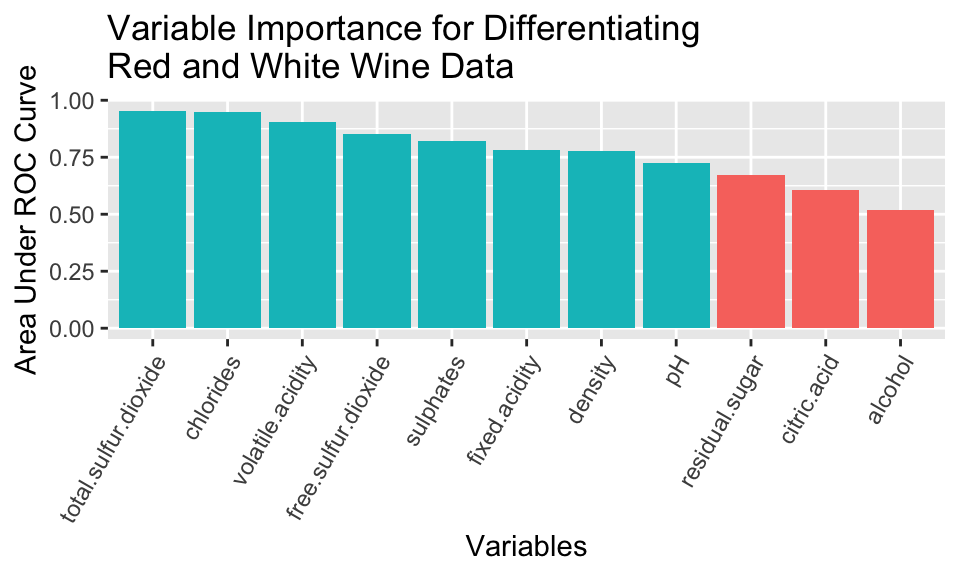

Figure 6: Variable that are most important in classifying Red and White wine

The three most important variables with classifying red and white wine are total sulfur dioxide, chlorides and volatile acidity. The least important for classification are residual sugar, citric acid and alcohol.

# Discussion

The purpose of this report was to identify the patterns present in the dataset by performing principal component analysis and accurately classify the wine type using a number of supervised classification techniques. This discussion will firstly discuss the findings in the PCA and then compare the supervised classification models.

### **Supervised Classification Findings**

The overall performance of the models can be attributed to evenly sampling the red and white wine observation from the raw dataset and normalising all numeric predictors. The data was purposefully sampled to create a new data frame containing an equal amount of red and white observations. This even distribution of observations yielded higher performance metrics across the models. The Z score normalisation method was purposefully choses to reduce the effect of outliers by not remove them from the dataset, thus protecting the data integrity of the dataset (Gullion, Devous Sr, and Rush (1996)). Gullion, Devous Sr, and Rush (1996) stated that before normalising the data, the dataset must be understood as various normalization method has substantial but different effects on characteristics of the data and statistical results.

# Conclusion

Overall, the analysis performed on the wine quality dataset gave various insights into the respective differences between red and white wines and indicated LDA was the most accurate method of supervised classification. PCA revealed that the red and white wine observation formed two distinctive clusters with majority of the variation occurring for the first 7 PCs. Overall all classification algorithms were accurately performed due to the pre-processing decisions enacted on the data prior to training the algorithms.

LDA was the most accurate supervised classification method followed by KNN due to the separation of red and white clusters. Thus LDA was able to classify each respective wine class in each linear boundary with great accuracy. The most important aspects when classifying red and white wines was sulfur dioxide, chlorides and volatile acidity whilst the least important aspects in differentiating was residual sugar, citric acid and alcohol. This indicates that the important aspects used in classifying red and white wine are most likely due to the inherent differences that occur during the fermentation process whilst the least important aspect for classification are the characteristics similar between red and wine observations occur in the production of these wine.

# References

Afendras, Georgios, and Marianthi Markatou. 2019. “Optimality of Training/Test Size and Resampling Effectiveness in Cross-Validation.” *Journal of Statistical Planning and Inference* 199. Elsevier: 286–301.

Ballester, Jordi, Hervé Abdi, Jennifer Langlois, Dominique Peyron, and Dominique Valentin. 2009. “The Odor of Colors: Can Wine Experts and Novices Distinguish the Odors of White, Red, and Rosé Wines?” *Chemosensory Perception* 2 (4). Springer: 203.

Camiz, Sergio, and Valério D Pillar. 2018. “Identifying the Informational/Signal Dimension in Principal Component Analysis.” *Mathematics* 6 (11). Multidisciplinary Digital Publishing Institute: 269.

del-Campo-Sanchez, Ana, Rocio Ballesteros, David Hernandez-Lopez, J Fernando Ortega, Miguel A Moreno, Agroforestry, Cartography Precision Research Group, and others. 2019. “Quantifying the Effect of Jacobiasca Lybica Pest on Vineyards with Uavs by Combining Geometric and Computer Vision Techniques.” *PloS One* 14 (4). Public Library of Science.

Elliott, David B, and Mark A Bullimore. 1993. “Assessing the Reliability, Discriminative Ability, and Validity of Disability Glare Tests.” *Investigative Ophthalmology & Visual Science* 34 (1). The Association for Research in Vision; Ophthalmology: 108–19.

Ferreira, Vicente, Felipe San Juan, Ana Escudero, Laura Cullere, Purificacion Fernandez-Zurbano, M Pilar Saenz-Navajas, and Juan Cacho. 2009. “Modeling Quality of Premium Spanish Red Wines from Gas Chromatography- Olfactometry Data.” *Journal of Agricultural and Food Chemistry* 57 (16). ACS Publications: 7490–8.

Gullion, Christina M, Michael D Devous Sr, and A John Rush. 1996. “Effects of Four Normalizing Methods on Data Analytic Results in Functional Brain Imaging.” *Biological Psychiatry* 40 (11). Elsevier: 1106–21.

Harrell, Frank E, Jr. 2020. *Hmisc: Harrell Miscellaneous*. https://CRAN.R-project.org/package=Hmisc.

Horikoshi, Masaaki, and Yuan Tang. 2020. *Ggfortify: Data Visualization Tools for Statistical Analysis Results*. https://CRAN.R-project.org/package=ggfortify.

Kuhn, Max. 2020. *Caret: Classification and Regression Training*. https://CRAN.R-project.org/package=caret.

Li, Haiyun, Haifeng Li, and Kaibin Wei. 2018. “Automatic Fast Double Knn Classification Algorithm Based on Acc and Hierarchical Clustering for Big Data.” *International Journal of Communication Systems* 31 (16). Wiley Online Library: e3488.

Majka, Michal. 2020. *Naivebayes: High Performance Implementation of the Naive Bayes Algorithm*. https://CRAN.R-project.org/package=naivebayes.

Ripley, Brian. 2019a. *Class: Functions for Classification*. https://CRAN.R-project.org/package=class.

———. 2019b. *MASS: Support Functions and Datasets for Venables and Ripley’s Mass*. https://CRAN.R-project.org/package=MASS.

Sing, Tobias, Oliver Sander, Niko Beerenwinkel, and Thomas Lengauer. 2015. *ROCR: Visualizing the Performance of Scoring Classifiers*. https://CRAN.R-project.org/package=ROCR.

Stephens, Christopher R, Hugo Flores Huerta, and Ana Ruı'z Linares. 2018. “When Is the Naive Bayes Approximation Not so Naive?” *Machine Learning* 107 (2). Springer: 397–441.

“Washington: For Bing’s Kevin White, Red Wine and Data Science Are the Perfect Pairing.” 2014. *US Official News*.

Wei, Taiyun, and Viliam Simko. 2017. *Corrplot: Visualization of a Correlation Matrix*. https://CRAN.R-project.org/package=corrplot.

Wickham, Hadley. 2018. *Reshape: Flexibly Reshape Data*. https://CRAN.R-project.org/package=reshape.

———. 2019. *Tidyverse: Easily Install and Load the ’Tidyverse’*. https://CRAN.R-project.org/package=tidyverse.

Wickham, Hadley, Winston Chang, Lionel Henry, Thomas Lin Pedersen, Kohske Takahashi, Claus Wilke, Kara Woo, and Hiroaki Yutani. 2019. *Ggplot2: Create Elegant Data Visualisations Using the Grammar of Graphics*. https://CRAN.R-project.org/package=ggplot2.

Wu, W, Y Mallet, B Walczak, W Penninckx, DL Massart, S Heuerding, and F Erni. 1996. “Comparison of Regularized Discriminant Analysis Linear Discriminant Analysis and Quadratic Discriminant Analysis Applied to Nir Data.” *Analytica Chimica Acta* 329 (3). Elsevier: 257–65.

Xie, Yihui. 2019. *Knitr: A General-Purpose Package for Dynamic Report Generation in R*. https://CRAN.R-project.org/package=knitr.

Zhang, Zhongheng, and Adela Castelló. 2017. “Principal Components Analysis in Clinical Studies.” *Annals of Translational Medicine* 5 (17). AME Publications.

Zhu, Hao. 2019. *KableExtra: Construct Complex Table with ’Kable’ and Pipe Syntax*. https://CRAN.R-project.org/package=kableExtra.